# Wprowadzenie do programowania w R

### 3.2.4. Operacje wykonywane na wektorach

W rozdziale 2 poznałeś operatory arytmemytyczne. W ramach tego rozdziału nauczymy się je wykorzystywać w odniesieniu do wektorów.

**Operacja na wektorach i liczbach**

Podstawowowym typem operacji jest: wektor - operator - liczba = wyniki. W tym przypadku operacje wykonywane są dla każdego elemente wektora. Operacja ta jest podobna do funkcji przeciągania w exelu. Zróbmy kilka przykładów.

```r
a <- c(1:4) # Tworzymy dwa wektor a
b <- seq(2,8,2) # Tworzymy dwa wektor b

a ; a+2 # wyświelt, wykonaj dodawanie
```

```
## [1] 1 2 3 4
```

```
## [1] 3 4 5 6
```

```r
a ; a-2
```

```
## [1] 1 2 3 4
```

```
## [1] -1  0  1  2
```

```r
a ; a*2
```

```
## [1] 1 2 3 4
```

```
## [1] 2 4 6 8
```

```r
a ; a/2
```

```
## [1] 1 2 3 4
```

```
## [1] 0.5 1.0 1.5 2.0
```

```r
a ; a^2
```

```
## [1] 1 2 3 4
```

```
## [1]  1  4  9 16
```

```r
a ; a%/%2 # cz. całkowita
```

```
## [1] 1 2 3 4
```

```
## [1] 0 1 1 2
```

```r
a ; a%%2 # reszta z dzielenia
```

```
## [1] 1 2 3 4
```

```
## [1] 1 0 1 0
```

**Operacje na równych wektorach**

Dobrze, teraz sprawdzimy jak są wykonywane operacje arytmetyczne na dwóch wektorach. W tym przypadku każdy element wektora jest mnożony, dodwany itd.. przez odpowiedni element wektora drugiego. Odpowiedni, tzn. znajdujący się w tym samym położeniu, lub o tych samych indeksach. Przyjrzyj się ponizsyzm przykłądom, by lepiej zrozumieć tą operację.

```r
a ; b ; a+b
```

```
## [1] 1 2 3 4
```

```
## [1] 2 4 6 8
```

```
## [1]  3  6  9 12
```

```r
a ; b ; a-b
```

```
## [1] 1 2 3 4
```

```
## [1] 2 4 6 8
```

```
## [1] -1 -2 -3 -4
```

```r
a ; b ; a*b
```

```
## [1] 1 2 3 4
```

```
## [1] 2 4 6 8
```

```
## [1]  2  8 18 32
```

```r
a ; b ; a/b
```

```
## [1] 1 2 3 4
```

```
## [1] 2 4 6 8
```

```
## [1] 0.5 0.5 0.5 0.5
```

```r
a ; b ; a^b
```

```
## [1] 1 2 3 4
```

```
## [1] 2 4 6 8
```

```
## [1]     1    16   729 65536
```

**Wektory o róznych długościach**

W przypadku wektorów o róznych długościach stosowana jest tzw. reguła zawijania wektora. Oznacza to, że wektor krótszy jest powielany, aż wykona wrzystkie operacje na wektorze dłuższym. Przyjrzyjmy się przykładom.

```r
a <- seq(8)
b <- c(2,4)

a; b; b*a
```

```
## [1] 1 2 3 4 5 6 7 8
```

```
## [1] 2 4
```

```
## [1]  2  8  6 16 10 24 14 32
```

```r
a; b; b-a
```

```
## [1] 1 2 3 4 5 6 7 8
```

```
## [1] 2 4
```

```
## [1]  1  2 -1  0 -3 -2 -5 -4
```

```r
a; b; b+a
```

```
## [1] 1 2 3 4 5 6 7 8
```

```
## [1] 2 4
```

```
## [1]  3  6  5  8  7 10  9 12
```

```r
a; b; b^a
```

```
## [1] 1 2 3 4 5 6 7 8
```

```
## [1] 2 4
```

```
## [1]     2    16     8   256    32  4096   128 65536
```

Analogiczną operację, można wykonać stosując funkcje `rep()` dla wektora b.

```r
a <- seq(8)
b <- c(2,4)
b <- rep(b,4)

a; b; b*a
```

```
## [1] 1 2 3 4 5 6 7 8
```

```
## [1] 2 4 2 4 2 4 2 4
```

```
## [1]  2  8  6 16 10 24 14 32
```

```r
a; b; b-a
```

```
## [1] 1 2 3 4 5 6 7 8
```

```
## [1] 2 4 2 4 2 4 2 4
```

```
## [1]  1  2 -1  0 -3 -2 -5 -4
```

Tak, wyniki są identyczne. Mam nadzieje, że jest to już zrozumiałe. Teraz w ramach ćwiczenai spróbuja wykonać operacje arytmetyczne na wektorach, które składają sie z 2 elementów i 3 elementów. np. `a = 1:3`, `b = c(4,2)`. Zastanów się jak w tym pryzpadku zadziała **reguła zawiajania**.

**Operacje relacyjne**

Na wektorach mozemy oczywiście wykonywać róWnież operacje relacyjne, o czym już wspominaliśmy. W tym przypadku róWnież obowiązuje reguła zawijania. Wykonajmy kilka prostych przykładów.

```r
x <- c(1,5,7,5) # tworzymy wektory
y <- c(4,2,9,5)
```

```r
x; y; x > y # czy mniejszy ?
x; y; x < y # czy większy ?
x; y; x <= y # czy nie większy ?
x; y; x >= y # czy nie mniejszy ?
x; y; x == y # czy równy ?
x; y; x != y # czy różny ?
```

Być może tabelaryczne zestawienie wyników, będzie czytelniejsze:

[output not shown]

**operacje logiczne**

Zasady wykonywania operacji logicznych już znacie, więc tylko krtótkie przypomnienie z zastosowaniem do wektorów.

```r
a <- c(TRUE, FALSE, NA) # Tworzymy wektory wartości logicznych
b <- c(T, F, NA) # to samo, ale prosty zapis

a ; !a # ! negacja
```

```
## [1]  TRUE FALSE    NA
```

```
## [1] FALSE  TRUE    NA
```

```r
b ; !b # ! negacja
```

```
## [1]  TRUE FALSE    NA
```

```
## [1] FALSE  TRUE    NA
```

```r
T  |  b # | alternatywa
```

```
## [1] TRUE TRUE TRUE
```

```r
F  |  b # | alternatywa
```

```
## [1]  TRUE FALSE    NA
```

```r
NA |  b # | alternatywa
```

```
## [1] TRUE   NA   NA
```

```r
T  & a # & koniunkcja
```

```
## [1]  TRUE FALSE    NA
```

```r
F  & a # & koniunkcja
```

```
## [1] FALSE FALSE FALSE
```

```r
NA & a # & koniunkcja
```

```
## [1]    NA FALSE    NA
```

Zwróć uwagę, że uwzgledniono wartość `NA`. Natomiast trzeba uważać z wykonywaniem operacji logicznych na wektoach liczbowych. Spróbojmy dodać, odjąć i pomnożyć wektor wartosci liczbowych, przez wektor wartości logicznych.

```r
a <- c(T, T, F, F, NA, NA)
b <- 1:6

a; b; a+b
```

```
## [1]  TRUE  TRUE FALSE FALSE    NA    NA
```

```
## [1] 1 2 3 4 5 6
```

```
## [1]  2  3  3  4 NA NA
```

```r
a; b; a-b
```

```
## [1]  TRUE  TRUE FALSE FALSE    NA    NA
```

```
## [1] 1 2 3 4 5 6
```

```
## [1]  0 -1 -3 -4 NA NA
```

```r
a; b; a*b
```

```
## [1]  TRUE  TRUE FALSE FALSE    NA    NA
```

```
## [1] 1 2 3 4 5 6
```

```
## [1]  1  2  0  0 NA NA
```

```r
a; b; a/b
```

```
## [1]  TRUE  TRUE FALSE FALSE    NA    NA
```

```
## [1] 1 2 3 4 5 6
```

```
## [1] 1.0 0.5 0.0 0.0  NA  NA
```

Wynikiem są liczby, dlaczego ? Przyjrzyj się, poprzednim przykładom i zauważ że wartość logiczna `TRUE` w operacjach arytmetycznych z wektorem liczbowym działa jak `1`, a wartość `FALSE` przyjmuje `0`. Prostym przykąłdem udowodnienia tego jest wykonanie konwersji wektora wartości `logical` na typ `integer`.

```r
as.integer(a)
```

```
## [1]  1  1  0  0 NA NA
```

**Modyfikacje elementów wektora**

Częstym przypadkiem jest wprowadzenie błędnych wartości w wektorze, czy zestawie danych, które są nieprawidłowe. W celu podmiany lub zmiany wybranych elmentów wektora korzystamy z wyrażeń modyfikacji wektora.

```r
# tworzymy wektor
x <- seq(1,5,0.8)
y <- 1:length(a)
```

```r
# Podmieniamy 1-elemenet wektora
x[1] <- 1.2 ; x
```

```
## [1] 1.2 1.8 2.6 3.4 4.2 5.0
```

```r
# podmieniamy 6 element (ostatni)
x[6] <- 5.1 ; x
```

```
## [1] 1.2 1.8 2.6 3.4 4.2 5.1
```

```r
# j.w inny sposób
x[length(x)] <- 7 ;x
```

```
## [1] 1.2 1.8 2.6 3.4 4.2 7.0
```

```r
# podmieniamy 2-elementy, [2:3]
x[2:3] <- c(5,5) ; x
```

```
## [1] 1.2 5.0 5.0 3.4 4.2 7.0
```

```r
# podmieniamy 3 pierwsze elementy wektora x wekotem y
x[1:3] <- y[1:3]
x;y
```

```
## [1] 1.0 2.0 3.0 3.4 4.2 7.0
```

```
## [1] 1 2 3 4 5 6
```

```r
x == y
```

```
## [1]  TRUE  TRUE  TRUE FALSE FALSE FALSE
```

```r
# reguła zawijania, co podmieniamy za co ?
x
```

```
## [1] 1.0 2.0 3.0 3.4 4.2 7.0
```

```r
x[-(1:4)] <- 100
x
```

```
## [1]   1.0   2.0   3.0   3.4 100.0 100.0
```

### 3.2.5. Funkcje działajace na elementach wektorach

Operacje arytmetyczne na każdym elemencie wektora możemy wykonywać przy pomocy różnego rodzaju funkcji dostępnych w R. Wiele z tych funkcji omówilismy w ramach rozdziału 2.

```r
x <- seq(2,20,4) # tworzymy wektor
```

Teraz wykonamy eperacje pierwiastkowania, logarytmowania, podniesiemy do potęgi x.

```r
x ; sqrt(x)
```

```
## [1]  2  6 10 14 18
```

```
## [1] 1.414214 2.449490 3.162278 3.741657 4.242641
```

```r
x ; exp(x)# funkcja wykładnicza każdy element e^x, a e=2.71
```

```
## [1]  2  6 10 14 18
```

```
## [1] 7.389056e+00 4.034288e+02 2.202647e+04 1.202604e+06 6.565997e+07
```

```r
x ; log(x, 10)
```

```
## [1]  2  6 10 14 18
```

```
## [1] 0.3010300 0.7781513 1.0000000 1.1461280 1.2552725
```

Otrzymane wyniki mają wiele miejsc po przecinku, aby ograniczyć ich ilość skorzystamy z funkcji `round()`

```r
x ; round(log(x, 10),2)
```

```
## [1]  2  6 10 14 18
```

```
## [1] 0.30 0.78 1.00 1.15 1.26
```

W przypadku wektora wartości odatnich i ujemnych można wyliczyć wartości bezwględne elementóW wektora np.:

```r
x <- seq(-100,100,25)
x ; abs(x)
```

```
## [1] -100  -75  -50  -25    0   25   50   75  100
```

```
## [1] 100  75  50  25   0  25  50  75 100
```

Pamietaj, że gdy stosujemy wiele funkcji operacje są wykonywane w określonej kolejności. Możemy również stosować w tym przypadku operacje indeksowania.= np.:

```r
x ; round(log(x[x>0], 10) * (3/2), 2)
```

```
## [1] -100  -75  -50  -25    0   25   50   75  100
```

```
## [1] 2.10 2.55 2.81 3.00
```

Najpierw indeksowanie `[x>0]` większych od zera, potem logarymt dziesietnych z większych od zera `log(x,10)`, nastepnie mnożenie wyniku logarytmowania `*(3/2)` i na końcu zaokrąglenie wyniku do dwóch miejsc po przecinku `round(,2)`.

W określonych sytuacjach koniecznym jest uporządkowanie wartości liczbowych, np.: gdy chcemy określić charakterytykę naszego zbioru danych. Służa do tego funkcje `sort()` i `order()`

Zanim zacznimy z nich korzystać posłużymy się prostą funkcją generowania wektorów liczb losowych `sample`. Funkcja ta na podstawie zadane wekrtora `x`, generuje wektor wartości losowych o okreslinej licznośc `size`. Możemy również określić, czy chcemy aby wartości wektora `x` były powtarzane lub nie `replace = T or F`.

```r
a <- sample(x = 1:4,   # wektor x
            size = 20, # liczność obserwacji wynikowego wektora
            replace = T) # powtarzaj
a
```

```
##  [1] 3 4 1 3 4 2 2 2 3 2 2 1 1 4 1 3 3 4 3 4
```

Teraz korzystajć z funkcji sort() utworzymy wektory wartosci rosnących i malejacych

```r
sort(a) # rosnący
```

```
##  [1] 1 1 1 1 2 2 2 2 2 3 3 3 3 3 3 4 4 4 4 4
```

```r
sort(a, decreasing = F) # j.w.
```

```
##  [1] 1 1 1 1 2 2 2 2 2 3 3 3 3 3 3 4 4 4 4 4
```

```r
sort(a, decreasing = T) # malejący
```

```
##  [1] 4 4 4 4 4 3 3 3 3 3 3 2 2 2 2 2 1 1 1 1
```

### 3.2.6. Funkcje wektorów

Do celów ćwiczenia wygenerujemy dwa 100-elementowe wektory

```r
a <- sample(x = 1:10, size = 100, replace = T) # powtarzaj
b <- sample(x = c(1:5,NA), size = 100, replace = T) # powtarzaj
```

```r
max(a) ; max(b)
```

```
## [1] 10
```

```
## [1] NA
```

Zauważ, że w przypadku wektora b otrzymaliśmy wartość `NA`, w przypadku tego typu wektora możemy zgodnie z naszą wiedzą usunąć wartości `NA`, podmienić je inną wartością liczbową, lub poprostu pominąć poprzez wykorzystanie argumentu `na.rm = T`

```r
max(a) ; max(b, na.rm = T)
```

```
## [1] 10
```

```
## [1] 5
```

```r
# lub
max(b[!is.na(b)]) # z indeksowaniem
```

```
## [1] 5
```

```r
# lub
b[is.na(b)]<- 6 # podmiana NA na 3
max(b) # podmiana
```

```
## [1] 6
```

Argument `na.rm = T`, ma zastosowanie do wrzystkich wymienionych w tym rozdziale funkcji.

```r
b[b == 6]<- NA # powrót do NA
```

```r
max(a); min(a); mean(a); median(a); sum(a)
```

```
## [1] 10
```

```
## [1] 1
```

```
## [1] 5.49
```

```
## [1] 5
```

```
## [1] 549
```

```r
prod(a) # ilosczyn
```

```
## [1] 5.005475e+65
```

```r
sd(a) # odch.stand.
```

```
## [1] 2.931869
```

```r
var(a) #wariancja
```

```
## [1] 8.595859
```

Teraz na wektorze `b` z wartościami `NA`

```r
max(b, na.rm=T); min(b, na.rm=T); mean(b, na.rm=T); median(b, na.rm=T); sum(b, na.rm=T)
```

```
## [1] 5
```

```
## [1] 1
```

```
## [1] 3.314607
```

```
## [1] 4
```

```
## [1] 295
```

```r
prod(b, na.rm=T)
```

```
## [1] 4.231665e+40
```

```r
sd(b, na.rm=T)
```

```
## [1] 1.512039
```

```r
var(b, na.rm=T)
```

```
## [1] 2.286261
```

Istnieją róWnież bardziej wyrafinowane funkcje, które zwracają od razu większą ilość parametróW. Funkcja `range()` zwraca zakres danych, czyli max i min z wektora.

```r
range(a) ; range(b)
```

```
## [1]  1 10
```

```
## [1] NA NA
```

Charakterystykę próbki możemy określić również przy pomocy funkcji: `unique()`, `table()`, `summary()`.

Funkcja `unique()` zwraca wektor wartości unikalnych

```r
unique(a)
```

```
##  [1] 10  2  7  4  6  1  8  9  3  5
```

```r
unique(b, na.rm = T)
```

```
## [1]  3  2  4  5 NA  1
```

Możemy to przedstawić w troszkę bardziej przyjemny dla oka sposób.

```r
sort(unique(a))
```

```
##  [1]  1  2  3  4  5  6  7  8  9 10
```

```r
sort(unique(b, na.rm = T))
```

```
## [1] 1 2 3 4 5
```

Funkcja `table()` zwraca informacje o liczności każdego elementu np.:

```r
a <- sample(seq(1,2,by = 0.1), size = 100, replace = T)
sort(unique(a))
```

```
##  [1] 1.0 1.1 1.2 1.3 1.4 1.5 1.6 1.7 1.8 1.9 2.0
```

```r
sort(table(a))
```

```
## a
##   1 1.4 1.2 1.3 1.7 1.8 1.9 1.6   2 1.5 1.1
##   4   6   7   7   7   7   9  12  12  14  15
```

Wynikiem jest wektor, w którym nazwy to unikalne wartosci wektora, a w drugiej kolumnie mamy liczność występowania każdej wartości. Najcześćie występowała wartość:

```r
max(table(a))
```

```
## [1] 15
```

najrzadziej wartość:

```r
min(table(a))
```

```
## [1] 4
```

a liczność naszych obserwacji (ilość elmentów wektora to):

```r
sum(table(a)) ; length(a) ; sum(table(a)) == length(a)
```

```
## [1] 100
```

```
## [1] 100
```

```
## [1] TRUE
```

Funkcja `table()` zwraca nam ilość poszczególnych obserwacji, co graficznie można przedstawić za pomocą histogramu. Histogram przedstawia liczność wartości każdego przedziału.

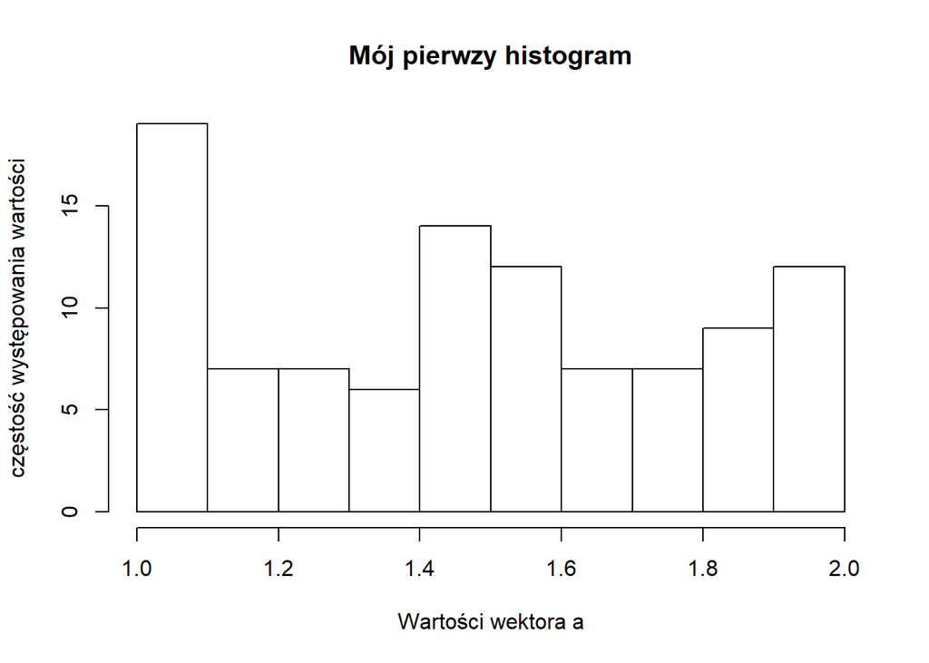

```r
hist(a,
     main = "Mój pierwzy histogram",
     xlab = "Wartości wektora a",
     ylab = "częstość występowania wartości")
```

Oprócz liczności próbkę danych możemy scharakteryzować przy pomocy kwantyli, do tego celu służą dwie funkcje:

- `summary()` - zwraca kwartyle, mediane oraz średnią
- `quantile()` - zwraca określony kwantyl

Przetestujmy funkcje summary

```r
summary(a)
```

```
##    Min. 1st Qu.  Median    Mean 3rd Qu.    Max.
##   1.000   1.200   1.500   1.522   1.800   2.000
```

```r
summary(b) # działa nawet na brakach danych NA
```

```
##    Min. 1st Qu.  Median    Mean 3rd Qu.    Max.    NA's
##   1.000   2.000   4.000   3.315   5.000   5.000      11
```

Zauważ, żę wynikiem funkcji są:

- minimum (pierwsz wartość zbioru danych)
- 1 kwartyl (poniżej tej wartości zanjduje się 25% obserwacji)
- mediane (poniżej i powyżej ttej obserwacji znajduje się 50 % obserwacji)
- średnią
- 3 kwartyl (poniżej tej wartości znajduje się 75% obserwacji)
- maksimum (ostatnia wartość zbioru danych)

Powyższe wartości możemy przedstawić na prostym wykresie ramka wąsy:

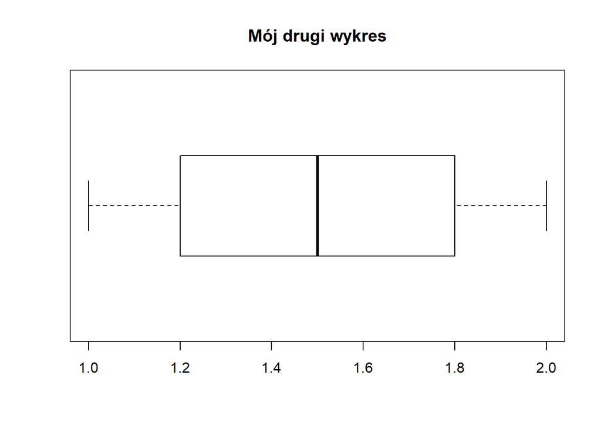

```r
boxplot(a, horizontal = T, main = "Mój drugi wykres")
```

Wąsy to min i max, ramka to 1 i 3 kwartyl, a pogrubiona czarna linia to mediana.

Kolejną fukcją, która pozwoli nam przybliżyć charakterystykę liczbową naszej próbki jest funkcja `quantile()`.

```r
quantile(a) # analogia summary - bez średniej
```

```
##   0%  25%  50%  75% 100%
##  1.0  1.2  1.5  1.8  2.0
```

Możemy również wybrać kwantyl, który chcemy policzyć.

```r
quantile(a, probs = 0.25)
```

```
## 25%
## 1.2
```

```r
quantile(a, probs = c(0.25, 0.5))
```

```
## 25% 50%
## 1.2 1.5
```

Policzymy teraz decyle:

```r
quantile(a, probs = seq(0,1,0.1))
```

```
##   0%  10%  20%  30%  40%  50%  60%  70%  80%  90% 100%
##  1.0  1.1  1.2  1.3  1.5  1.5  1.6  1.7  1.9  2.0  2.0
```

### 3.2.7. Funkcje generowania wartości losowych

Często bardzo przydatne są funkcje generowania wektorów wartości losowych. Możemy skorzystać z kilku funkcji, które generują zbior wartości o rozkładzie normalnym, o rozkładzie Poissona, czy Bernoulliego. Przedstawimu tylko dwie funkcje, pierwsza to `rnorm()` - generuje zbioró wartosci o rozkładzie normalnym, oraz funkcji `runif()`, która generuje wektor wartości losowych.

```r
rk1 <- rnorm(n = 100) # podajemy tylko liczbe elementów wektora n
rk2 <- runif(n = 100, min =2, max = 5) # podajemy n, wartość min i max.
```

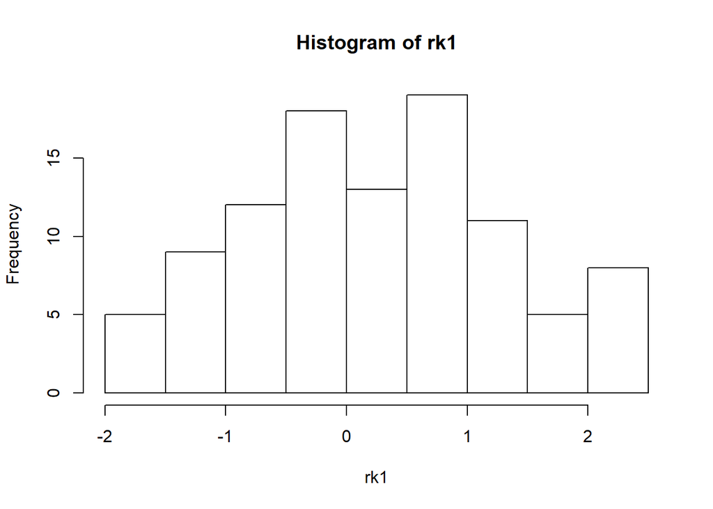

```r
hist(rk1)
```

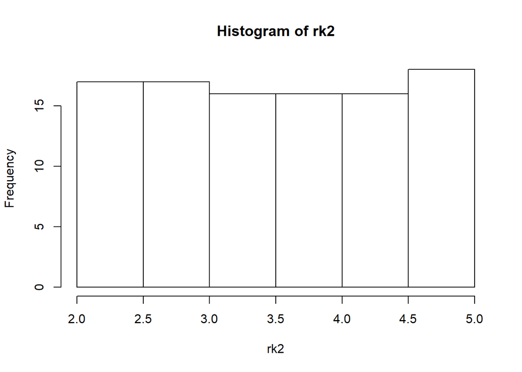

```r
hist(rk2)
```

## 3.3. Listy

Lista. Podobnie jak wektor, lista to również uporządkowany zbiór elementów. W przeciwieństwie do wektora, elementy listy mogą mieć różne typy. Podobnie jak w przypadku wektora poszczególne elementy mogą mieć nazwy. Listy tworzy się zazwyczaj z użyciem funkcji `list()`. Wykonaj polecenie i przyglądnij się wynikowi.

```r
al <- list(imie=c("Jan","Tomasz"), nazwisko="Kowalski",
           wiek=25, czyWZwiazku=T)
al
```

```
## $imie
## [1] "Jan"    "Tomasz"
##
## $nazwisko
## [1] "Kowalski"
##
## $wiek
## [1] 25
##
## $czyWZwiazku
## [1] TRUE
```

Lista skłąda się z 4 nadrzędnych elementów, tj. imie, nazwisko, itd.., Zaleta listy jest to, że może przechowywać różnego typu wartosci, np. `character`, `logical`, czy `numeric`.

##### ćwiczenie 7

###### Treść

Wykonaj listę charakterystyczną dla książki adresowej dostępnej np. smart fonie z którego korzystacie. Ma zawierać dane dla 3 osób:

- Nazwisko i Imię,
- Adres (dokładny - jakbyście wysyłali list),
- Numer telefonu prywatnego,
- Numer telefonu służbowego,
- Miejsce pracy i nazwa uczelni na której studiuje,
- Adres mailowy (prywatny i służbowy)

Listę umieść w zmiennej o nazwie: kontak

Następnie wykonaj kilka poniższych poleceń oraz wyjaśnij co zwraca każde polecenie (wyjaśnienia umieść w skrypcie w postaci komentarzy)

- `length(kontak)`
- `is.vector(kontakt)`
- `is.atomic(kontakt)`
- `typeof(kontakt)`
- `class(kontakt)`
- `str(kontakt)`

###### odp.

```r
kontakt <- list(nazwisko = c("Borsuk", "Koliber", "Tygrys"),
                imie = c("Karol", "Eliza", "Anastazia"),
                kod_pocztowy = c("33-178", "30-877","30-854"),
                nr_budynku = c(5, 6, 2),
                nr_lokalu = c(85, 32, NA),
                woj = c("Opolskie", "Ślaskie", "Mazowieckie"),
                tel_pr = c(505359357, 505234234, 676888965),
                tel_sl = c(607000222, 611222333, 666999777) ,
                firma = c("EB", "KHK", "ZKM"),
                uczelnia = c("AGH", "PK", "AGH"),
                email = c("bk@agh.pl", "ke@agh.pl","ta@agh.pl")
)

kontakt
```

```
## $nazwisko
## [1] "Borsuk"  "Koliber" "Tygrys"
##
## $imie
## [1] "Karol"     "Eliza"     "Anastazia"
##
## $kod_pocztowy
## [1] "33-178" "30-877" "30-854"
##
## $nr_budynku
## [1] 5 6 2
##
## $nr_lokalu
## [1] 85 32 NA
##
## $woj
## [1] "Opolskie"    "Ślaskie"     "Mazowieckie"
##
## $tel_pr
## [1] 505359357 505234234 676888965
##
## $tel_sl
## [1] 607000222 611222333 666999777
##
## $firma
## [1] "EB"  "KHK" "ZKM"
##
## $uczelnia
## [1] "AGH" "PK"  "AGH"
##
## $email
## [1] "bk@agh.pl" "ke@agh.pl" "ta@agh.pl"
```

```r
length(kontakt) # lista zawiera 11 atrybutów
```

```
## [1] 11
```

```r
is.vector(kontakt) # tak
```

```
## [1] TRUE
```

```r
is.atomic(kontakt) # nie atomowy
```

```
## [1] FALSE
```

```r
typeof(kontakt) # typ obiektu lista
```

```
## [1] "list"
```

```r
class(kontakt) # obiekt klasy lista
```

```
## [1] "list"
```

```r
str(kontakt) # struktura obiekty
```

```
## List of 11
##  $ nazwisko    : chr [1:3] "Borsuk" "Koliber" "Tygrys"
##  $ imie        : chr [1:3] "Karol" "Eliza" "Anastazia"
##  $ kod_pocztowy: chr [1:3] "33-178" "30-877" "30-854"
##  $ nr_budynku  : num [1:3] 5 6 2
##  $ nr_lokalu   : num [1:3] 85 32 NA
##  $ woj         : chr [1:3] "Opolskie" "Ślaskie" "Mazowieckie"
##  $ tel_pr      : num [1:3] 5.05e+08 5.05e+08 6.77e+08
##  $ tel_sl      : num [1:3] 6.07e+08 6.11e+08 6.67e+08
##  $ firma       : chr [1:3] "EB" "KHK" "ZKM"
##  $ uczelnia    : chr [1:3] "AGH" "PK" "AGH"
##  $ email       : chr [1:3] "bk@agh.pl" "ke@agh.pl" "ta@agh.pl"
```

**Ciekawostka**

Przy pomocy polecenia `data.frame()` przekształcimy obiekt typu lista na obiekt typu ramka danych. Oraz go wyświetlimy.

```r
View(books <- data.frame(kontakt))
```

```r
books <- data.frame(al)
View(books)
```

O obiektach `data.frame()`, powiemy więcej w rozdziale 3.5:

### 3.3.1. Indeksowanie listy

Do elementów listy możemy się odwoływać jak do elementów wektora, korzystając z nazw poszczególnych pól lub z operatora [] (operator ten został wyjaśniony w rozdziale dotyczącym indeksowania). W poniższym przykładzie konstruujemy listę czterech obiektów różnych typów.

```r
al[1] # odwołanie do atrybutu listy
```

```
## $imie
## [1] "Jan"    "Tomasz"
```

```r
al[3]
```

```
## $wiek
## [1] 25
```

Jeśli chcemy wykonywać operacje na obiekcie listy, to stosujemy podwójny indeksator `[[x]]` lub `$`

```r
al[[3]] * 2
```

```
## [1] 50
```

```r
al$wiek * 2
```

```
## [1] 50
```

Jeśli chcemy odwołać się do konkretnej wartości:

```r
al[[1]][2]
```

```
## [1] "Tomasz"
```

Podwójny nawias odwołuje się do atrybutu listy, a kolejny zestaw nawiasów do wektora.

### 3.3.2. Modyfikowanie list

Znamy zasady indeksowania, to modyfikacje są analogiczne jak w przypadku wektorów. Podmienimy zawartość atrybutu wiek.

```r
al$wiek <- c(23,35,77,58)
al
```

```
## $imie
## [1] "Jan"    "Tomasz"
##
## $nazwisko
## [1] "Kowalski"
##
## $wiek
## [1] 23 35 77 58
##
## $czyWZwiazku
## [1] TRUE
```

```r
al[[2]] <- c("Nowak","Kowalski", "Koper")
al
```

```
## $imie
## [1] "Jan"    "Tomasz"
##
## $nazwisko
## [1] "Nowak"    "Kowalski" "Koper"
##
## $wiek
## [1] 23 35 77 58
##
## $czyWZwiazku
## [1] TRUE
```

```r
l1 <- list(nowa = c(1:10))
l2 <- list(koniec = c(20:29))
lista <- c(l1,l2)
lista
```

```
## $nowa
##  [1]  1  2  3  4  5  6  7  8  9 10
##
## $koniec
##  [1] 20 21 22 23 24 25 26 27 28 29
```

### 3.3.2. Operacja na listach

Tak jak poprzednio, możemy wykonywać dodowlne opercja na poszczególnych atrybutach listy, ale musimy się do nich odwołać poprzez indeksowanie.

Przeprowadzimy kilka znanych nam operacji, ale najpier utworzymy listę przy pomocy poznanych funkcji:

```r
nowa <- list(waga = sample(50:80, replace = T, size = 5),
             wiek = round(runif(5, 25, 77),0),
             wzrost = sample(150:190, size = 5))
```

Teraz chcemy policzyć, średnią wagę, wiek, wzrost.

```r
mean(nowa) # nie działa
```

```
## [1] NA
```

Aby wykonać operacje musimy się odwołąć do każdego elementu listy.

```r
mean(nowa$waga)
```

```
## [1] 59
```

```r
mean(nowa[[2]]) # itd.
```

```
## [1] 44
```

Odwoływanie się do każdego elementu listy bywa bardzo męczące. W celu wykluczenia tego problemu możemy skorzystać z funkcji `lapply` i sapply. Wykonuje ona operacje na każdym obiekcie. Składnia jest analogiczna, podajemy nazwę naszej listy, a następnie podajemy nazwę funkcji z której chcemy skorzystać.

Rożnica jest taka, że wynikiem funkcji `lapply` jest dalej lista, a funkcji `sapply` jest wektor.

```r
lapply(nowa, mean) -> a ; a
```

```
## $waga
## [1] 59
##
## $wiek
## [1] 44
##
## $wzrost
## [1] 177
```

```r
sapply(nowa, mean) -> b ; b
```

```
##   waga   wiek wzrost
##     59     44    177
```

Wykonuje również inne operacje

```r
# Działą na funkcjach zwracających wektory
lapply(nowa, summary) -> a ; a # lista wektoróW
sapply(nowa, range) -> b ; b # ramka danych

# można odwrócić wartość liczby
lapply(nowa, "-") -> a ; a

# można przeliczyć każdy element
lapply(nowa, sqrt) -> a ; a
sapply(nowa, exp) -> b ; b

# można stosować argumenty funkcji, ale bez nawiasów
sapply(nowa, quantile) -> b ; b
sapply(nowa, quantile, prob = c(0.5,0.75)) -> b ; b # dodatkowy argument funkcji
```

## 3.4. Macierze

```r
matrix(data = 0, nrow = 2, ncol = 4)
```

```
##      [,1] [,2] [,3] [,4]
## [1,]    0    0    0    0
## [2,]    0    0    0    0
```

```r
# lub forma skrócona
matrix(0,2,4)
```

Drugi przykład macierzy z ciągiem arytmetycznym.

```r
matrix(1:6, nrow = 2, ncol = 3)
```

```
##      [,1] [,2] [,3]
## [1,]    1    3    5
## [2,]    2    4    6
```

Trzeci przykład macierzy z sekwencją.

```r
matrix(seq(3,8,1), nrow = 3, ncol = 2)
```

```
##      [,1] [,2]
## [1,]    3    6
## [2,]    4    7
## [3,]    5    8
```

Czwarty przykład z zastosowaniem funkcji c().

```r
x <- matrix(c(1,2,3,1:3,3:5), 3, 3)
x
```

```
##      [,1] [,2] [,3]
## [1,]    1    1    3
## [2,]    2    2    4
## [3,]    3    3    5
```

```r
x <- matrix(c(1,2,3,1:3,3:5), nrow = 3, ncol = 3)
x
```

```
##      [,1] [,2] [,3]
## [1,]    1    1    3
## [2,]    2    2    4
## [3,]    3    3    5
```

Macierz składająca się z elementów tekstowych.

```r
a <- c("A","B","C","D")
xx <- matrix(a,2,2)
```

Funkcją `array()` można również konstruować macierze, ale większej liczbie wymiarów. Tym zagadnieniem nie będziemy zajmować się w ramach tego kursu. Jeśli będziesz potrzebował kiedyś wiecej informacji, to znajdziesz je w Gagolewski (2014) oraz Biecek (2008).

#### ćwiczenie 8

##### Treść

Utwórz macierz: `matrix(1:6, nrow = 2, ncol = 3) -> xx` Następnie wykonaj następujące polecenia i wyjaśnij w komentarzach co one zwracają.

##### odp.

```r
matrix(1:6, nrow = 2, ncol = 3) -> xx
length(xx)
```

```
## [1] 6
```

```r
is.vector(xx)
```

```
## [1] FALSE
```

```r
is.atomic(xx)
```

```
## [1] TRUE
```

```r
typeof(xx)
```

```
## [1] "integer"
```

```r
class(xx)
```

```
## [1] "matrix"
```

```r
nrow(xx)
```

```
## [1] 2
```

```r
ncol(xx)
```

```
## [1] 3
```

## 3.5. Ramki danych

Szczególnym typem obiektu jest ramka danych, nazywana również tabelą danych. Ramka danych jest zazwyczaj z tabelaryczną strukturą, której elementy w każdej kolumnie są tego samego typu, ale mogą różnić się typami pomiędzy kolumnami. Z tego powodu ramkę danych można traktować jak listę wektorów o tej samej długości, każdy wektor odpowiada jednej kolumnie. Ramki danych tworzy się zazwyczaj funkcją `data.frame()`.

Ramka danych jest oprócz wektora jednym z najczęściej wykorzystywanych typów obiektów i poświęcimy jej dość sporo uwagi.

```r
ramka <- data.frame(id = c(100,101,102),
                    wiek = c(25,21,22),
                    wzrost = seq(170,190,10),
                    chlopiec = c(TRUE,TRUE,FALSE))
ramka
```

```
##    id wiek wzrost chlopiec
## 1 100   25    170     TRUE
## 2 101   21    180     TRUE
## 3 102   22    190    FALSE
```

```r
View(ramka)
```

Do kolumn ramki danych (które są wektorami) możemy odwoływać się tak, jak do elementów macierzy, a także tak jak do elementów list przy pomocy operatora `$` dostępu do pól obiektu klasy S4.

```r
ramka$wiek
```

```
## [1] 25 21 22
```

wykonaj następujące polecenie i opisz co zwracają w komentarzach.

#### ćwiczenie 9

##### Treść

Stwórz dowolną tabele składająca się 10 wierszy i 4 kolumn. Pod zmienną `dane`. W kolumny od 1 do 4 mają przechowywać odpowiednio.

- liczby całkowite
- liczby rzeczywiste (do dwóch miejsc dzietnych)
- tekst
- zmienne logiczne
- Kolumny mają mieć też określone nazwy. Nazwy dowolne, ale krótkie (jedno słowo do 5 znaków).

wykonaj następujące polecenie dla obiektu dane oraz opisz co zwracają w komentarzach.

```r
length()
is.vector()
is.atomic()
is.data.frame()
is.array()
str(attributes())
typeof()
class()
nrow()
ncol()
dim()
colnames()
names()
row.names()
summary()
```

##### odp.

Stwórz dowolną tabele składająca się 10 wierszy i 4 kolumn. Pod zmienną `dane`. W kolumny od 1 do 4 mają przechowywać odpowiednio.

- liczby całkowite ,
- liczby rzeczywiste (do dwóch miejsc dzietnych)
- tekst
- zmienne logiczne
- Kolumny mają mieć też określone nazwy. Nazwy dowolne, ale krótkie (jedno słowo do 5 znaków).

```r
data.frame(calko = c(1:10),
           rzecz = seq(0.8,20, length.out = 10),
           tekst = letters[sample(1:26, replace = T, size = 10)],
           logic = as.logical(rep(0:1), 5)
           ) -> dane
dane ; View(dane)
```

```
##    calko     rzecz tekst logic
## 1      1  0.800000     k FALSE
## 2      2  2.933333     g  TRUE
## 3      3  5.066667     e FALSE
## 4      4  7.200000     f  TRUE
## 5      5  9.333333     o FALSE
## 6      6 11.466667     l  TRUE
## 7      7 13.600000     m FALSE
## 8      8 15.733333     t  TRUE
## 9      9 17.866667     p FALSE
## 10    10 20.000000     f  TRUE
```

wykonaj następujące polecenie dla obiektu dane oraz opisz co zwracają w komentarzach.

```r
length(dane)
```

```
## [1] 4
```

```r
is.vector(dane)
```

```
## [1] FALSE
```

```r
is.atomic(dane)
```

```
## [1] FALSE
```

```r
is.data.frame(dane)
```

```
## [1] TRUE
```

```r
is.array(dane)
```

```
## [1] FALSE
```

```r
str(attributes(dane))
```

```
## List of 3
##  $ names    : chr [1:4] "calko" "rzecz" "tekst" "logic"
##  $ class    : chr "data.frame"
##  $ row.names: int [1:10] 1 2 3 4 5 6 7 8 9 10
```

```r
str(dane) # bardzo pomocne
```

```
## 'data.frame':    10 obs. of  4 variables:
##  $ calko: int  1 2 3 4 5 6 7 8 9 10
##  $ rzecz: num  0.8 2.93 5.07 7.2 9.33 ...
##  $ tekst: Factor w/ 9 levels "e","f","g","k",..: 4 3 1 2 7 5 6 9 8 2
##  $ logic: logi  FALSE TRUE FALSE TRUE FALSE TRUE ...
```

```r
typeof(dane)
```

```
## [1] "list"
```

```r
class(dane)
```

```
## [1] "data.frame"
```

```r
nrow(dane)
```

```
## [1] 10
```

```r
ncol(dane)
```

```
## [1] 4
```

```r
dim(dane)
```

```
## [1] 10  4
```

```r
colnames(dane)
```

```
## [1] "calko" "rzecz" "tekst" "logic"
```

```r
names(dane) # j.w
```

```
## [1] "calko" "rzecz" "tekst" "logic"
```

```r
row.names(dane)
```

```
##  [1] "1"  "2"  "3"  "4"  "5"  "6"  "7"  "8"  "9"  "10"
```

```r
summary(dane)
```

```
##      calko           rzecz          tekst     logic
##  Min.   : 1.00   Min.   : 0.8   f      :2   Mode :logical
##  1st Qu.: 3.25   1st Qu.: 5.6   e      :1   FALSE:5
##  Median : 5.50   Median :10.4   g      :1   TRUE :5
##  Mean   : 5.50   Mean   :10.4   k      :1
##  3rd Qu.: 7.75   3rd Qu.:15.2   l      :1
##  Max.   :10.00   Max.   :20.0   m      :1
##                                 (Other):3
```

Zauważ, że w zależności od typu danych zawartych w kolumnie funkcja summary zwraca różne informacje. Pamietasz funkcje `table()`. Porównaj wyniki z funkcją `summary()`

```r
table(dane$tekst)
```

```
##
## e f g k l m o p t
## 1 2 1 1 1 1 1 1 1
```

## 3.5.1. Indeksowanie

Najpierw załadujemy zestaw danych. W folderze który pobrałeś z [upel](http://upel.agh.edu.pl/wggiis/) znajduje się plik `dane.RData`.

Sprawdzć, czy masz odpowiedni obszar roboczy:

```r
getwd()
```

```
## [1] "Z:/R/Kurs_R"
```

Jeśli nie to poleceniem `setwd("...")` ustaw go na folder w którym znajduje się plik z danymi, *gdzie 3 kropki to ścieżka dostępu*.

Poleceniem `dir()` sprawdzć jakie plki i foldery znajdują się w twoim katalogu.

```r
dir()
```

Jeśli jest tam plik `dane.RData`, to wykonaj polecenia ładowania.

```r
load(file = "dane.RData")
```

W prawym górnym oknie powinien pojawić się obiek dane, który ma następującą postać:

```r
dane
```

```
##        imie Nazwisko praca   stanow Zarobki staz urlop Waga Wzrost Wiek
## 1 Katarzyna Kowalska   AGH asystent  5013.6   19     4   63    160   38
## 2     Zofia Kowalska   ZUS księgowy  2919.0    6    19   55    177   47
## 3     Julia Kowalska   NFZ księgowy  3117.8   15     9   80    188   33
## 4      Kora    Nowak   AGH  adniunk  2074.7    5     3   74    164   42
## 5     Piotr   Zwykły    PK    prof.  2753.6    6     3   81    167   56
## 6      Adam     Nowy    UJ    prof.  4950.1   10     9   71    179   47
## 7    Robert     Nowy    UG    prof.  5489.3    9    12   58    184   28
## 8    Robert     Ptak   NFZ  technik  2698.0   16     2   59    173   58
## 9     Beata     Ptak   UMK Inżynier  2058.7    9     4   60    189   41
##   Plec Kraj
## 1    M   DE
## 2    M   PL
## 3    M  USA
## 4    K   PL
## 5    K   DE
## 6    M  USA
## 7    K  USA
## 8    K  USA
## 9    M   PL
```

```r
View(dane)
```

# 4. Cechy jakościowe

# 5. Cechy ilościowe

# 4. Wczytywanie danych

# 5. Przetwarzanie tekstu

# 6. Przetwarzanie daty

Biecek, Przemysław. 2008. *Przewodnik po pakiecie R*. Oficyna wydawnicza GIS.

Gagolewski, Marek. 2014. *Programowanie w jȩzyku R: Analiza danych, obliczenia, symulacje, Warszawa*. Warszawa: Wydawnictwo Naukowe PWN.